# Workshop Week 9

Author

Affiliation

STAT5003

School of Mathematics and Statistics

# 1 Learning Outcomes

**Learning Outcomes**

- Explore feature selection
  1. Apply `leaps::regsubsets` to perform Subset features with forward and backward selection
  2. Apply `glmnet` package to perform LASSO regression for feature selection
  3. Apply `glmnet` package to perform Ridge regression for feature selection
  4. Evaluate the benefits of using different forms of feature selection

# 2 Loading Packages

At the start of your R workshop, load all necessary packages to ensure a smooth session. Here’s an example:

```r
library(tidyverse)  # Data science packages
library(ggplot2)    # Data visualization
library(ggthemes)   # Inclusive ggplot themes
library(here)       # File paths
library(rsample)    # Training/test sets split
library(caret)
library(ISLR2)      # Introduction to Statistical Learning 2nd Edition
library(leaps)      # Forward and Backward Stepwise Selection
library(glmnet)     # Lasso
library(kableExtra) # Creating Clean Tables
```

The dataset we are using is provided by the `ISLR2` package. It contains Major League Baseball Data from the 1986 and 1987 seasons with 322 observations with 20 variables. It has some missing cases that isn’t the focus of this workshop and can be removed with the following code.

```r
data(Hitters, package = "ISLR2")
Hitters <- na.omit(Hitters)
```

# 3 Forward selection

Use `leaps::regsubsets` to implement a forward stepwise selection procedure with up to 21 predictors (*why 21 predictors?*). The response variable here is `Salary` which is numeric, so this is a regression and not a classification problem.

- The model size (number of predictors) that minimises the BIC.
- The model size that minimises the Cp statistic.
- The model size that maximises the adjusted $R^2$.

```r
step_fwd = regsubsets(Salary ~., data = Hitters, nvmax = 21, method = "forward")

step_summary <- summary(step_fwd)


# Extract minimum or maximum for each metric
model_summary <- data.frame(
  Criterion = c("BIC", "Cp", "Adjusted R-squared"),
  Value = c(
    min(step_summary$bic, na.rm = TRUE),
    min(step_summary$cp, na.rm = TRUE),
    max(step_summary$adjr2, na.rm = TRUE)
  ),
  Best_Model_Size = c(
    which.min(step_summary$bic),
    which.min(step_summary$cp),
    which.max(step_summary$adjr2)
  )
)

# Display a nice table
kable(model_summary, "html", caption = "Best Model Size Based on Different Criteria") %>%
  kable_styling(bootstrap_options = c("striped", "hover", "condensed"), full_width = FALSE)
```

Best Model Size Based on Different Criteria

| Criterion | Value | Best_Model_Size |
| --- | --- | --- |
| BIC | -147.9169040 | 6 |
| Cp | 5.0093172 | 10 |
| Adjusted R-squared | 0.5225706 | 11 |

We can see that the forward stepwise selection algorithm has selected different numbers of features based on three indirect estimates of the test errors. Since the number of observations is greater than 8, and thus BIC penalises the model complexity heavier, resulting in the smallest model out of the three.

# 4 Lasso regression

**Split data and fit**

Split the dataset into 60% train and 40% test (feel free to do this using either `caret`, `rsample` or manually). Perform a lasso regression using the `glmnet`.

```r
set.seed(5003)
inTrain <- createDataPartition(Hitters$Salary, p = .6)[[1]] # Doing a 60% training split

# Convert to design matrix format
x <- model.matrix(Salary ~ ., Hitters)[,-1]
y <- Hitters$Salary
```

**Inspect coefficients as function of \(\lambda\)**

Plot the lasso regression coefficients as a function of $\lambda$. Use cross-validation to find the best $\lambda$ value (You can use the inbuilt CV function in glmnet - `cv.glmnet`). Support your answer with a visualization of the selection of $\lambda$.

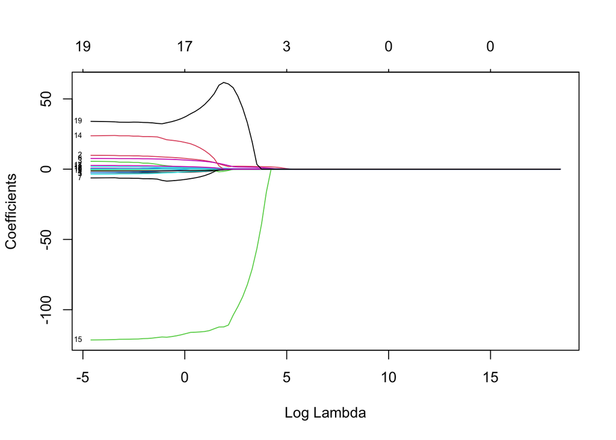

```r
# set the range of lambda values to be tested. From the largest value of lambda to the smallest value.
grid <- 10^seq(8, -2, length = 100)

# Set alpha = 1 for Lasso, alpha = 0 for Ridge and 0 < alpha < 1 for the elastic net
lasso.mod <- glmnet(x[inTrain,],
                    y[inTrain],
                    alpha = 1, lambda = grid, standardize = TRUE)

plot(lasso.mod, xvar="lambda", label=TRUE)
```

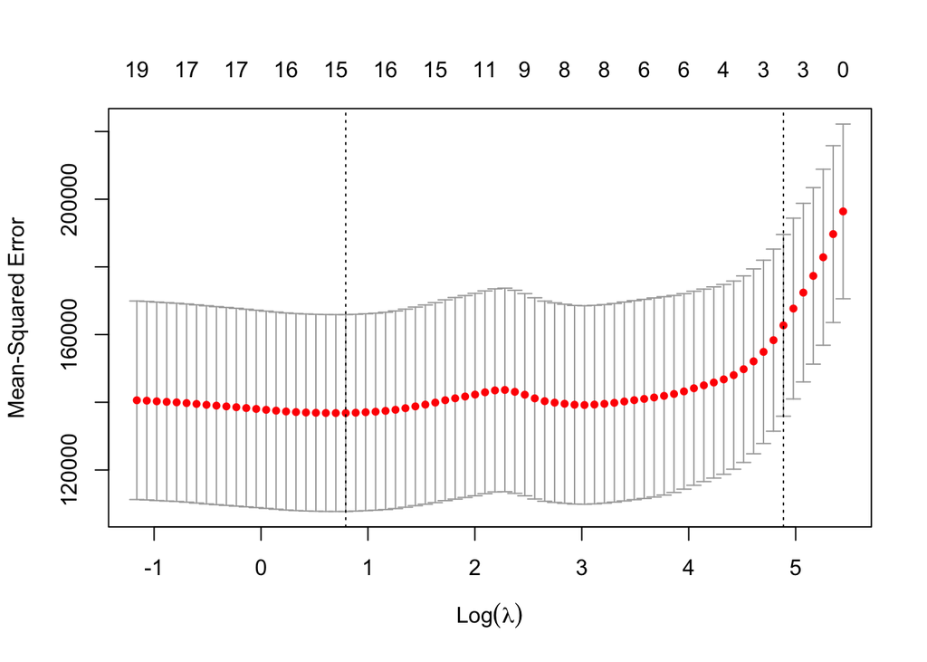

```r
# Using the inbuilt function to do cross-validation
set.seed(5003)
cv.out <- cv.glmnet(x[inTrain,],
                    y[inTrain],
                    alpha = 1)

plot(cv.out)
```

```r
# Get the best lambda
bestlam <- cv.out$lambda.min
bestlam
```

```
[1] 2.208513
```

**Check if model is sparse**

Inspect the coefficients in the best model above and check if there are any coefficients that have been shrunk to zero. The `cv.glmnet` function returns a list. Inspect the list and the outputs of the `cv.glmnet` function in order to find where the best lambda can be extracted.

```r
# Extract the features for the best fit
best.betas <- cv.out$glmnet.fit$beta[, which(cv.out$lambda == bestlam)]
best.betas
```

```
        AtBat          Hits         HmRun          Runs           RBI
  -1.76577152    6.48114951    0.00000000    0.00000000   -1.44544643
        Walks         Years        CAtBat         CHits        CHmRun
   5.79862262   -5.35438837    0.00000000    0.00000000    1.04088941
        CRuns          CRBI        CWalks       LeagueN     DivisionW
   0.98184889    0.13613502   -0.94897151   14.53718542 -115.76422927
      PutOuts       Assists        Errors    NewLeagueN
   0.22074412    0.04672062    1.47561529   44.01087464
```

We can see straight away that some of the features here have been converted to 0.

These are the coefficients that have been converted to 0:

```r
# Shrunken betas (zero)
shrunk.betas <- best.betas[best.betas == 0]
shrunk.betas
```

```
 HmRun   Runs CAtBat  CHits
     0      0      0      0
```

And these are the coefficients that have remained:

```r
# Non-zero betas
non.zero.betas <- best.betas[best.betas != 0]
non.zero.betas
```

```
        AtBat          Hits           RBI         Walks         Years
  -1.76577152    6.48114951   -1.44544643    5.79862262   -5.35438837
       CHmRun         CRuns          CRBI        CWalks       LeagueN
   1.04088941    0.98184889    0.13613502   -0.94897151   14.53718542
    DivisionW       PutOuts       Assists        Errors    NewLeagueN
-115.76422927    0.22074412    0.04672062    1.47561529   44.01087464
```

**Assess on the test set**

Using the optimal trained model predict the salary of the test dataset and calculate the mean squared error.

```r
# Use the best CV model to predict the test set Salary
test.pred <- predict(cv.out, x[-inTrain,])[,1]
mse.lasso <- mean((test.pred - y[-inTrain])^2)
print(mse.lasso)
```

```
[1] 159812.4
```

# 5 Ridge regression [Take-Home Exercise]

Repeat the previous question with the Ridge. Perform ridge regression with the `glmnet` package on the dataset.

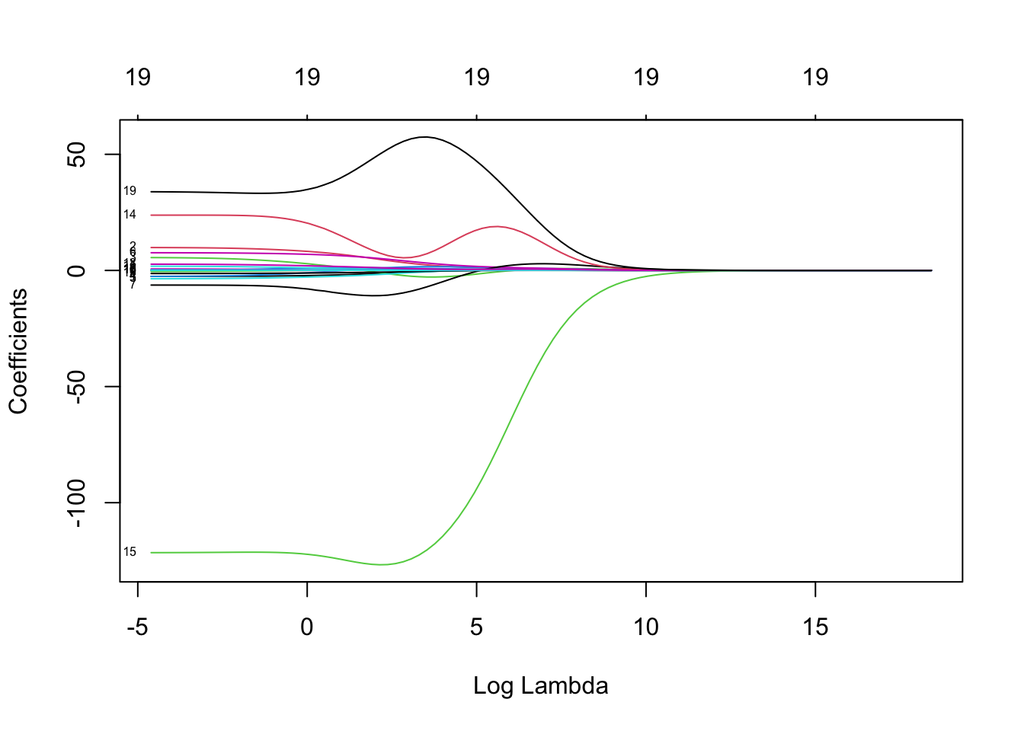

```r
# Specifying alpha = 0 in order to specify ridge regression
ridge.mod <- glmnet(x[inTrain,],
                    y[inTrain],
                    alpha=0, lambda=grid, standardize = TRUE)

plot(ridge.mod, xvar="lambda", label=TRUE)
```

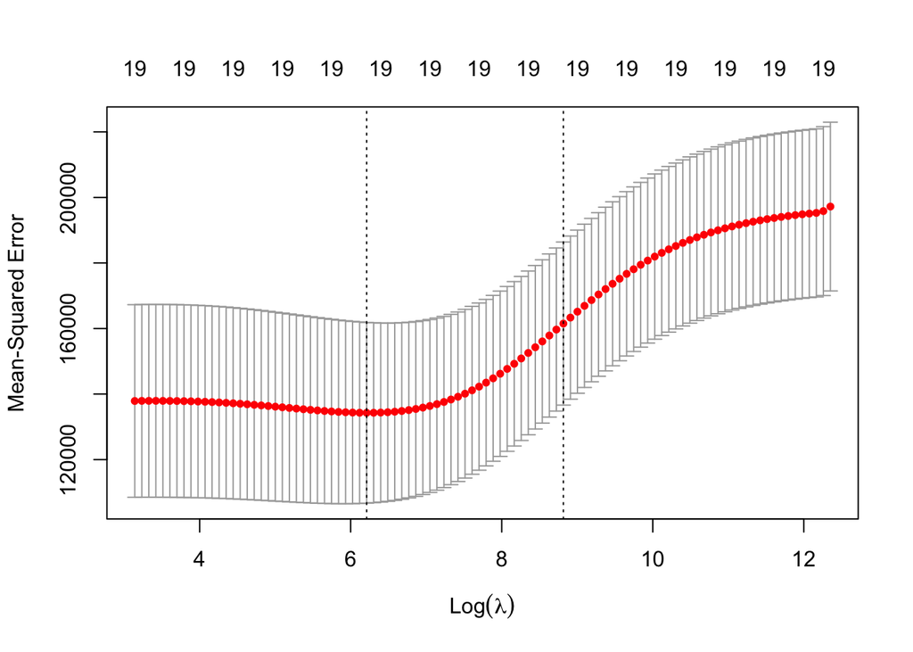

```r
# Using the inbuilt function to do cross-validation
set.seed(5003)
cv.out <- cv.glmnet(x[inTrain,],
                    y[inTrain],
                    alpha=0)
plot(cv.out)
```

```r
bestlam <- cv.out$lambda.min
bestlam
```

```
[1] 498.4656
```

```r
# Use the best CV model to predict the test set Salary
test.pred <- predict(cv.out, x[-inTrain,])[,1]
mse <- mean((test.pred - y[-inTrain])^2)
```